# DSO 522: In-Class Workbook 10

Matteo Sesia

October 29, 2024

# Instructions

Your task is to edit this R Markdown notebook to include your solutions, ensuring that it is well-organized and professional in appearance. Answers must be clear and concise. Start by downloading the Rmd file.

**Collaboration Policy.** You are allowed to discuss this workbook with your classmates and work in groups. Despite group discussions, each student must write and submit their own solutions.

**Assistance Policy.** You may ask for clarifications from the instructor and teaching assistant in class. Do not seek help on these workbooks outside of class, as they are intended to be completed during class time.

**Submission Requirements.** Solutions must be submitted on Brightspace as a PDF writeup. Use the ‘Knit to PDF’ feature in RStudio to prepare your PDF document. Ensure that your PDF document looks like the provided PDF version of the workbook, including all code used to obtain the results in proper code blocks. Make sure your PDF writeup includes *your name* in the title (replace my name with yours).

**Grading Criteria.** This workbook is worth 10 points. To achieve a grade of 10, your writeup must correctly answer all questions, be easy to understand, and be formatted correctly.

**Work Timeline.** You are expected to work on this assignment in class, but you may complete it at home within 24 hours. It is due on October 23, 2024, at 9:30 pm. Late submissions will incur a 50% deduction for any initial delay below 24 hours, and an additional 10% deduction for each additional day.

Remember, you will need to use the `fpp3` package to complete this assignment, as shown in the lecture.

```r
suppressMessages(library(fpp3))
```

# Problem 1

For the United States GDP series (from `global_economy`):

1. If necessary, find a suitable Box-Cox transformation for the data;
2. fit a suitable ARIMA model to the transformed data using `ARIMA()`;
3. try some other plausible models by experimenting with the orders chosen;
4. choose what you think is the best model and check the residual diagnostics;
5. produce forecasts of your fitted model. Do the forecasts look reasonable?
6. compare the results with what you would obtain using `ETS()` (with no transformation).

# Problem 1 Solutions

1. If necessary, find a suitable Box-Cox transformation for the data;

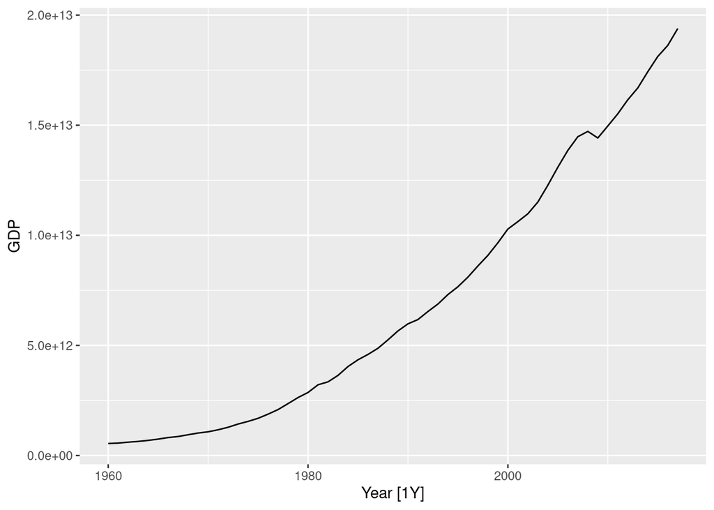

```r
us_economy <- global_economy |>
  filter(Code == "USA")
us_economy |>
  autoplot(GDP)
```

```r
lambda <- us_economy |>
  features(GDP, features = guerrero) |>
  pull(lambda_guerrero)
lambda
```

```
[1] 0.2819443
```

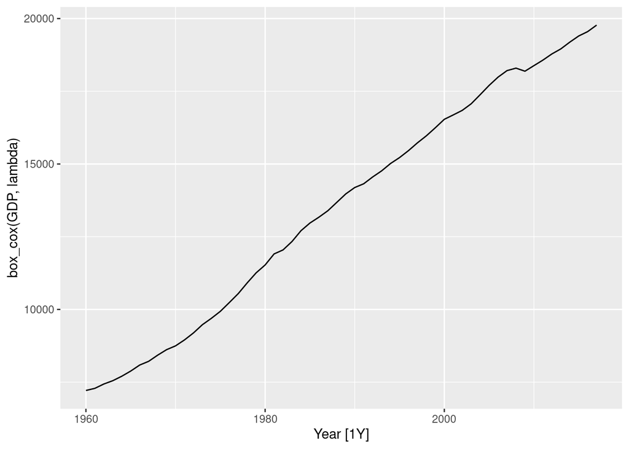

```r
us_economy |>
  autoplot(box_cox(GDP, lambda))
```

It seems that a Box-Cox transformation may be useful here.

2. fit a suitable ARIMA model to the transformed data using `ARIMA()`;

```r
fit <- us_economy |>
  model(ARIMA(box_cox(GDP, lambda)))
report(fit)
```

```
Series: GDP
Model: ARIMA(1,1,0) w/ drift
Transformation: box_cox(GDP, lambda)

Coefficients:
         ar1  constant
      0.4586  118.1822
s.e.  0.1198    9.5047

sigma^2 estimated as 5479:  log likelihood=-325.32
AIC=656.65   AICc=657.1   BIC=662.78
```

3. try some other plausible models by experimenting with the orders chosen;

```r
fit <- us_economy |>
  model(
    arima010 = ARIMA(box_cox(GDP, lambda) ~ 1 + pdq(0, 1, 0)),
    arima011 = ARIMA(box_cox(GDP, lambda) ~ 1 + pdq(0, 1, 1)),
    arima012 = ARIMA(box_cox(GDP, lambda) ~ 1 + pdq(0, 1, 2)),
    arima013 = ARIMA(box_cox(GDP, lambda) ~ 1 + pdq(0, 1, 3)),
    arima110 = ARIMA(box_cox(GDP, lambda) ~ 1 + pdq(1, 1, 0)),
    arima111 = ARIMA(box_cox(GDP, lambda) ~ 1 + pdq(1, 1, 1)),
    arima112 = ARIMA(box_cox(GDP, lambda) ~ 1 + pdq(1, 1, 2)),
    arima113 = ARIMA(box_cox(GDP, lambda) ~ 1 + pdq(1, 1, 3)),
    arima210 = ARIMA(box_cox(GDP, lambda) ~ 1 + pdq(2, 1, 0)),
    arima211 = ARIMA(box_cox(GDP, lambda) ~ 1 + pdq(2, 1, 1)),
    arima212 = ARIMA(box_cox(GDP, lambda) ~ 1 + pdq(2, 1, 2)),
    arima213 = ARIMA(box_cox(GDP, lambda) ~ 1 + pdq(2, 1, 3)),
    arima310 = ARIMA(box_cox(GDP, lambda) ~ 1 + pdq(3, 1, 0)),
    arima311 = ARIMA(box_cox(GDP, lambda) ~ 1 + pdq(3, 1, 1)),
    arima312 = ARIMA(box_cox(GDP, lambda) ~ 1 + pdq(3, 1, 2)),
    arima313 = ARIMA(box_cox(GDP, lambda) ~ 1 + pdq(3, 1, 3))
  )
```

4. choose what you think is the best model and check the residual diagnostics;

```r
fit |>
  glance() |>
  arrange(AICc) |>
  select(.model, AICc)
```

| .model | AICc |
| --- | --- |
| arima110 | 657.1005 |
| arima011 | 659.1845 |
| arima111 | 659.4135 |
| arima210 | 659.4141 |
| arima012 | 659.9375 |
| arima112 | 661.3123 |
| arima211 | 661.4642 |
| arima310 | 661.7258 |
| arima013 | 662.0334 |
| arima312 | 662.5982 |

[output cut: 6 more lines]

The best according to the AICc values is the ARIMA(1,1,0) w/ drift model.

```r
best_fit <- us_economy |>
  model(ARIMA(box_cox(GDP, lambda) ~ 1 + pdq(1, 1, 0)))
best_fit |> report()
```

```
Series: GDP
Model: ARIMA(1,1,0) w/ drift
Transformation: box_cox(GDP, lambda)

Coefficients:
         ar1  constant
      0.4586  118.1822
s.e.  0.1198    9.5047

sigma^2 estimated as 5479:  log likelihood=-325.32
AIC=656.65   AICc=657.1   BIC=662.78
```

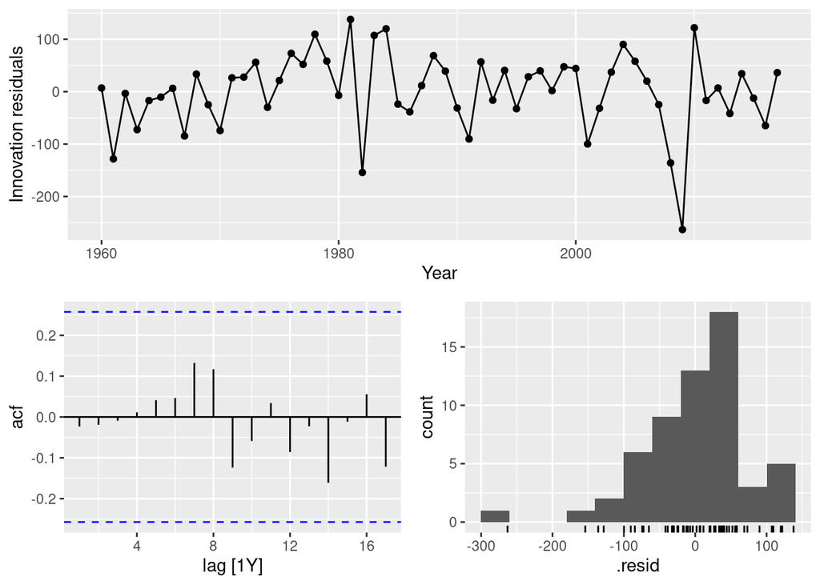

```r
best_fit |> gg_tsresiduals()
```

The residuals seem uncorrelated, but the histogram looks like negatively skewed.

5. produce forecasts of your fitted model. Do the forecasts look reasonable?

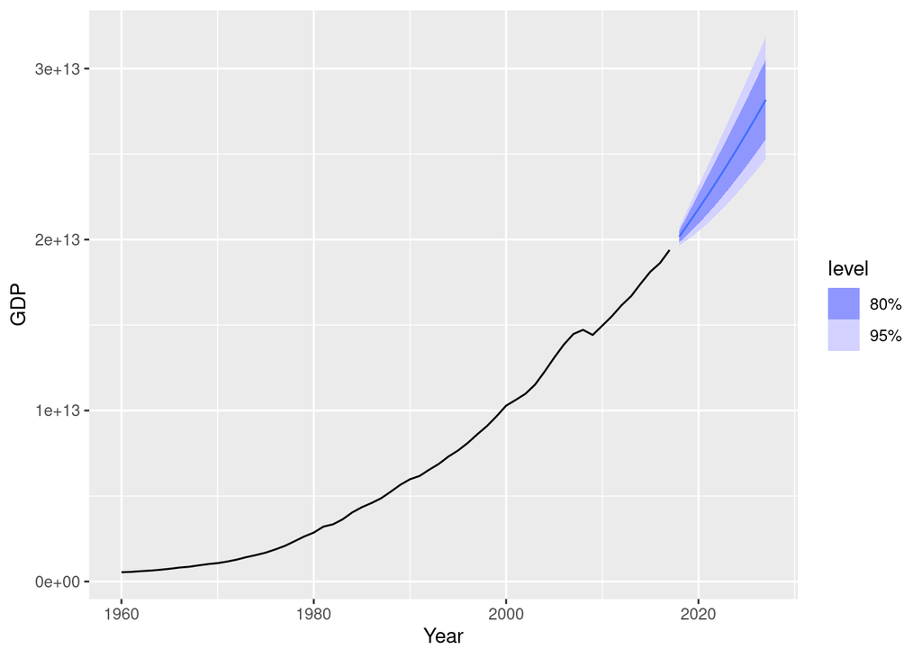

```r
best_fit |>
  forecast(h = 10) |>
  autoplot(us_economy)
```

These look reasonable. Let’s compare a model with no transformation.

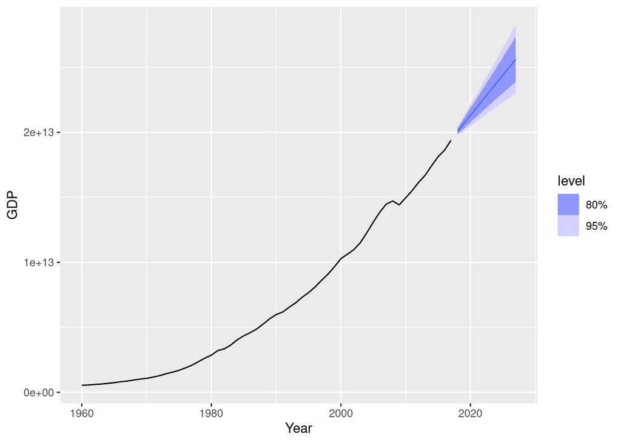

```r
fit1 <- us_economy |> model(ARIMA(GDP))
fit1 |>
  forecast(h = 10) |>
  autoplot(us_economy)
```

Notice the effect of the transformation on the forecasts. Increase the forecast horizon to see what happens. Notice also the width of the prediction intervals.

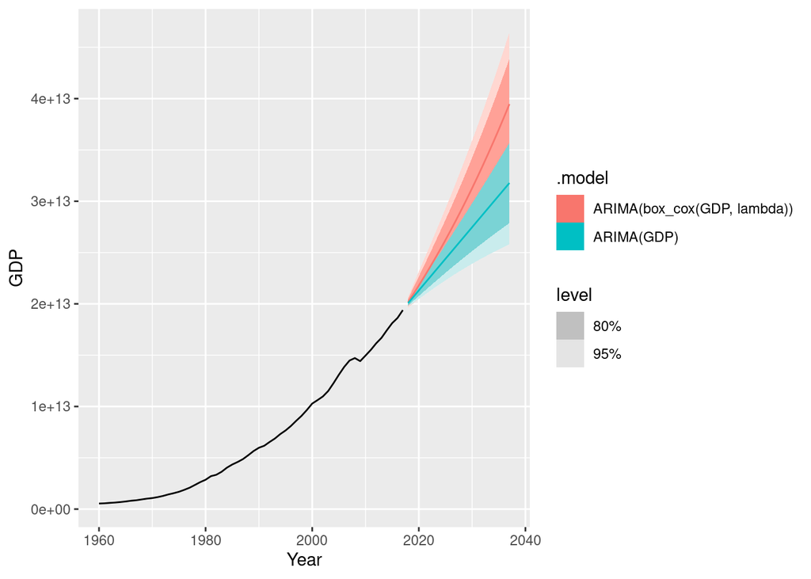

```r
us_economy |>
  model(
    ARIMA(GDP),
    ARIMA(box_cox(GDP, lambda))
  ) |>
  forecast(h = 20) |>
  autoplot(us_economy)
```

6. compare the results with what you would obtain using `ETS()` (with no transformation).

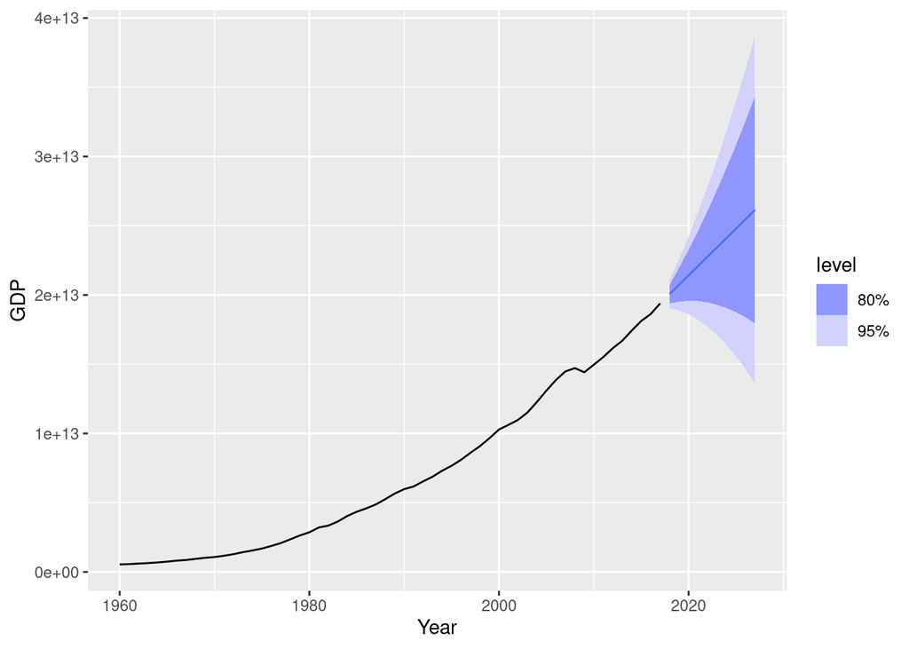

```r
us_economy |>
  model(ETS(GDP)) |>
  forecast(h = 10) |>
  autoplot(us_economy)
```

The point forecasts are similar, however the ETS forecast intervals are much wider.

# Problem 2

Consider the following seasonal time series: the Australian production of electricity, from `aus_production`.

1. Do the data need transforming? If so, find a suitable transformation.
2. Are the data stationary? If not, find an appropriate differencing which yields stationary data.
3. Identify a couple of ARIMA models that might be useful in describing the time series. Which of your models is the best according to their AIC values?
4. Estimate the parameters of your best model and do diagnostic testing on the residuals. Do the residuals resemble white noise? If not, try to find another ARIMA model which fits better.
5. Forecast the next 24 months of data using your preferred model.
6. Compare the forecasts obtained using `ETS()`.

# Problem 2 Solutions

1. Do the data need transforming? If so, find a suitable transformation.

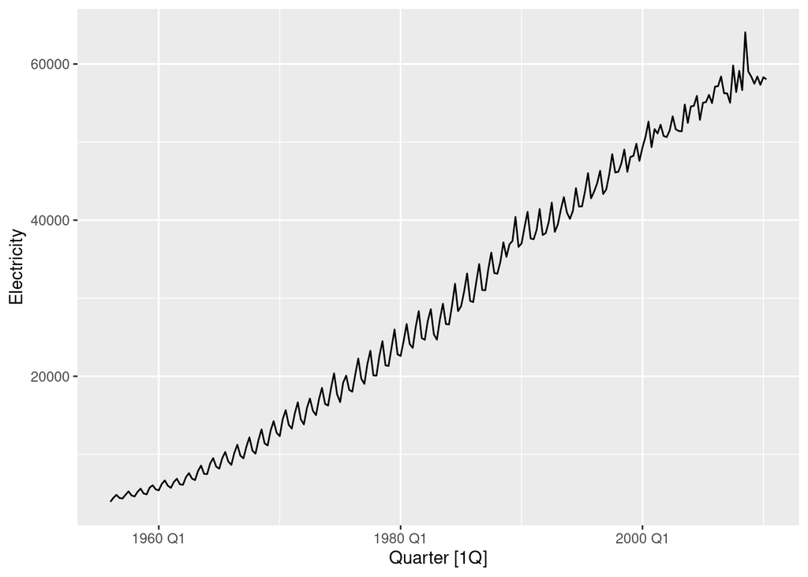

```r
aus_production |>
  autoplot(Electricity)
```

Yes, these need transforming.

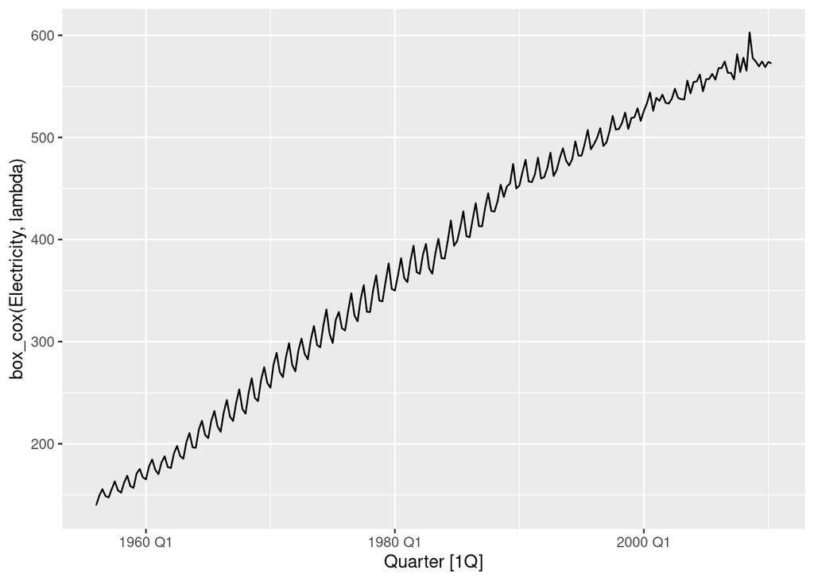

```r
lambda <- aus_production |>
  features(Electricity, guerrero) |>
  pull(lambda_guerrero)
aus_production |>
  autoplot(box_cox(Electricity, lambda))
```

`guerrero()` suggests using Box-Cox transformation with parameter $\lambda=0.52$.

2. Are the data stationary? If not, find an appropriate differencing which yields stationary data.

The trend and seasonality show that the data are not stationary.

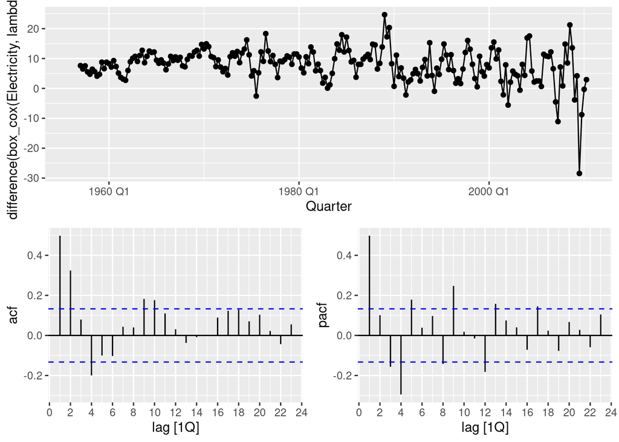

```r
aus_production |>
  gg_tsdisplay(box_cox(Electricity, lambda) |> difference(4), plot_type = "partial")
```

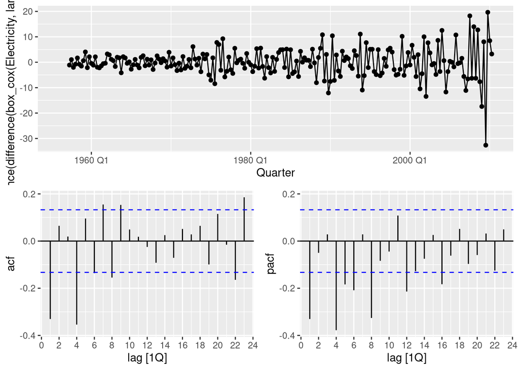

```r
aus_production |>
  gg_tsdisplay(box_cox(Electricity, lambda) |> difference(4) |> difference(1), plot_type = "partial")
```

- It seems that we could have continued with only taking seasonal differences. You may try this option.
- We opt to take a first order difference as well.
3. Identify a couple of ARIMA models that might be useful in describing the time series. Which of your models is the best according to their AIC values?

From the above graph, an AR(1) or an MA(1) with a seasonal MA(2) might work. So an ARIMA(1,1,0)(0,1,2) model for the transformed data.

```r
fit <- aus_production |>
  model(
    manual = ARIMA(box_cox(Electricity, lambda) ~ 0 + pdq(1, 1, 0) + PDQ(0, 1, 2)),
    auto = ARIMA(box_cox(Electricity, lambda))
  )
fit |>
  select(auto) |>
  report()
```

```
Series: Electricity
Model: ARIMA(1,1,4)(0,1,1)[4]
Transformation: box_cox(Electricity, lambda)

Coefficients:
          ar1     ma1      ma2      ma3      ma4     sma1
      -0.7030  0.2430  -0.4477  -0.1553  -0.2452  -0.5574
s.e.   0.1739  0.1943   0.0973   0.0931   0.1189   0.1087

sigma^2 estimated as 18.02:  log likelihood=-609.08
AIC=1232.17   AICc=1232.71   BIC=1255.7
```

```r
glance(fit)
```

| .model | sigma2 | log_lik | AIC | AICc | BIC | ar_roots | ma_roots |
| --- | --- | --- | --- | --- | --- | --- | --- |
| manual | 19.74855 | -619.7181 | 1247.436 | 1247.629 | 1260.881 |  |  |
| auto | 18.02156 | -609.0839 | 1232.168 | 1232.714 | 1255.697 |  |  |

Automatic model selection with `ARIMA()` has also taken a first order difference, and so we can compare the AICc values. This is a challenging ARIMA model to select manually and the automatic model is clearly better.

4. Estimate the parameters of your best model and do diagnostic testing on the residuals. Do the residuals resemble white noise? If not, try to find another ARIMA model which fits better.

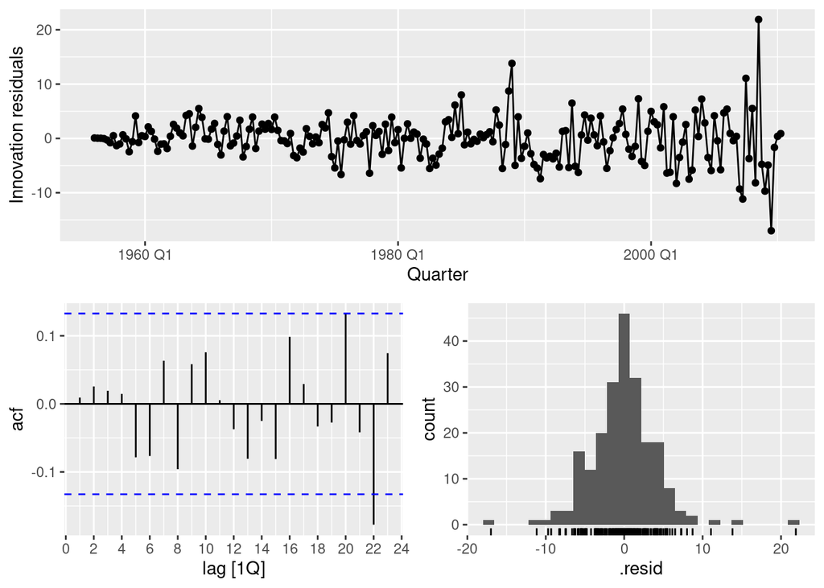

```r
fit |>
  select(auto) |>
  gg_tsresiduals()
```

```r
# to find out the dof for Ljung Box test
fit |> select(auto) |> report()
```

```
Series: Electricity
Model: ARIMA(1,1,4)(0,1,1)[4]
Transformation: box_cox(Electricity, lambda)

Coefficients:
          ar1     ma1      ma2      ma3      ma4     sma1
      -0.7030  0.2430  -0.4477  -0.1553  -0.2452  -0.5574
s.e.   0.1739  0.1943   0.0973   0.0931   0.1189   0.1087

sigma^2 estimated as 18.02:  log likelihood=-609.08
AIC=1232.17   AICc=1232.71   BIC=1255.7
```

```r
tidy(fit)
```

| .model | term | estimate | std.error | statistic | p.value |
| --- | --- | --- | --- | --- | --- |
| manual | ar1 | -0.34612279 | 0.06476561 | -5.3442375 | 2.328170e-07 |
| manual | sma1 | -0.73098480 | 0.08763405 | -8.3413335 | 9.158270e-15 |
| manual | sma2 | 0.08201814 | 0.08581468 | 0.9557588 | 3.402776e-01 |
| auto | ar1 | -0.70297705 | 0.17390523 | -4.0422997 | 7.394790e-05 |
| auto | ma1 | 0.24296519 | 0.19433265 | 1.2502541 | 2.125786e-01 |
| auto | ma2 | -0.44771968 | 0.09726396 | -4.6031405 | 7.148584e-06 |
| auto | ma3 | -0.15532065 | 0.09313440 | -1.6677045 | 9.684389e-02 |
| auto | ma4 | -0.24518598 | 0.11886740 | -2.0626849 | 4.035558e-02 |
| auto | sma1 | -0.55742763 | 0.10867186 | -5.1294569 | 6.522881e-07 |

```r
fit |>
  select(auto) |>
  augment() |>
  features(.innov, ljung_box, dof = 6, lag = 12)
```

| .model | lb_stat | lb_pvalue |
| --- | --- | --- |
| auto | 8.451472 | 0.206857 |

Residuals look reasonable, they resemble white noise.

5. Forecast the next 24 months of data using your preferred model.

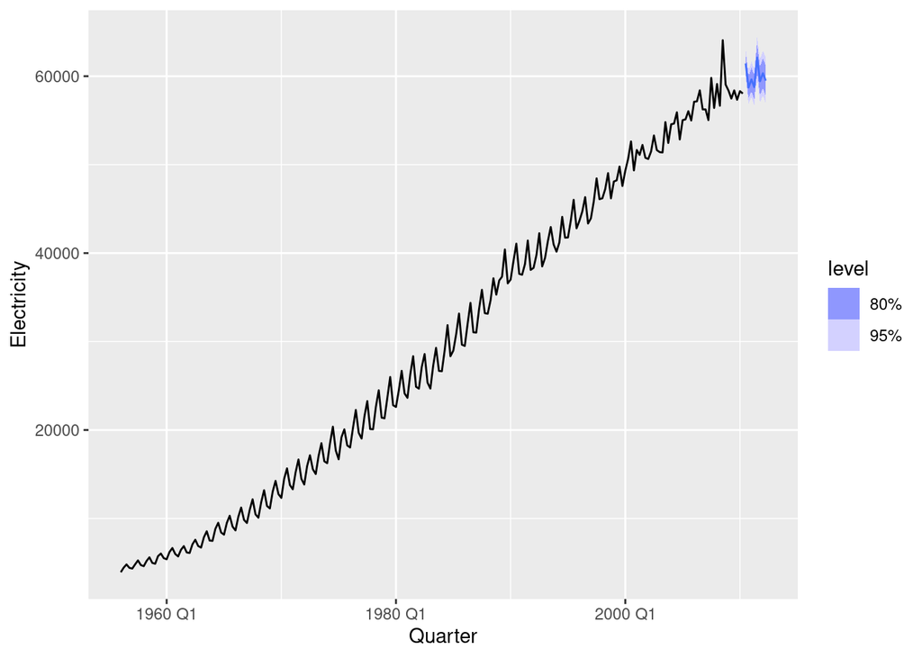

```r
fit |>
  select(auto) |>
  forecast(h = "2 years") |>
  autoplot(aus_production)
```

6. Compare the forecasts obtained using `ETS()`.

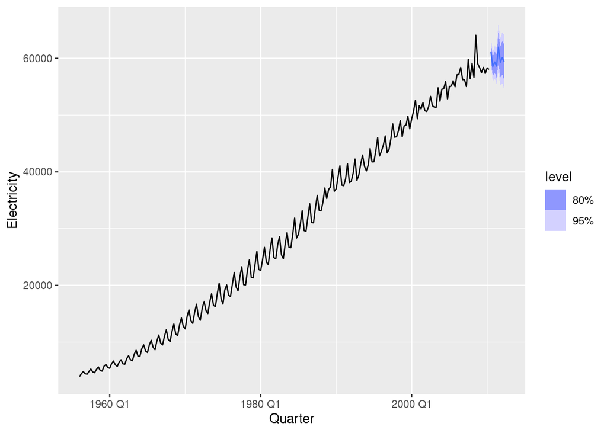

```r
aus_production |>
  model(ETS(Electricity)) |>
  forecast(h = "2 years") |>
  autoplot(aus_production)
```

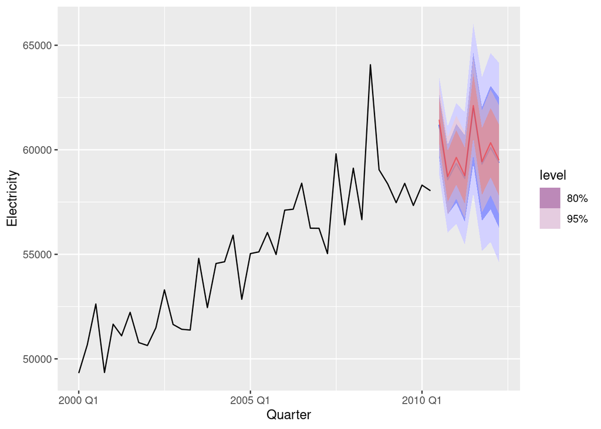

```r
aus_production |>
  model(ETS(Electricity)) |>
  forecast(h = "2 years") |>
  autoplot(aus_production |> filter(year(Quarter) >= 2000)) +
  autolayer(fit |> select(auto) |> forecast(h = "2 years"), colour = "red", alpha = 0.4)
```

- The point forecasts appear to be quite similar.
- The ETS forecasts have a wider forecast interval than the ARIMA forecasts.